# Análisis de Indicadores de Salud - Hepatitis B

Grupo 11

2026-04-07

# a) Aspectos metodológicos generales

## Fuente de datos

Los datos utilizados provienen de una base de datos estructurada que contiene información sobre características sociodemográficas y de salud relacionadas con la Hepatitis B.

## Universo o muestra

El análisis se realizó sobre una muestra de individuos registrada en la base de datos `datosHB`.

## Variables utilizadas

- Edad (`edad_num`)
- Sexo (`sexo`)
- Región (`region`)
- Grupo etario (`grupo_etario`)
- Nivel educativo (`Nivel educativo`)
- Afiliación a seguro (`ARS`)
- Diagnóstico presuntivo de Hepatitis B (`Sospecha`)

## Plan de análisis

Se desarrolló un análisis descriptivo que incluyó: - Construcción de indicadores - Desagregación por variables sociodemográficas - Estadísticas descriptivas - Análisis exploratorio (asimetría y curtosis) - Modelos de regresión y series de tiempo

# b) Objetivo general y específicos

## Objetivo general

Analizar indicadores relacionados con Hepatitis B y acceso a servicios de salud, considerando variables sociodemográficas.

## Objetivos específicos

- Construir indicadores de salud y aseguramiento
- Analizar su comportamiento por sexo, región y edad
- Evaluar la distribución de variables mediante estadística descriptiva
- Explorar patrones mediante modelos estadísticos

# c) Presentación de resultados

## Construcción de indicadores

```r
library(readxl)
datosHB <- read_excel("D:/Cursos/ENE (ONE)/R/BD-HB-2025.xlsx")
```

```r
###Para convertir nuestra columna que posee 20 años a solo 20 y sacar media, etc.
datosHB$edad_num <- as.numeric(gsub("[^0-9]", "", datosHB$Edad))
head(datosHB[, c("Edad", "edad_num")])
```

```
## # A tibble: 6 × 2
##   Edad    edad_num
##   <chr>      <dbl>
## 1 23 Años       23
## 2 1 Días         1
## 3 33 Años       33
## 4 36 Años       36
## 5 1 Días         1
## 6 55 Años       55
```

```r
###Remplazar las categorias de sexo que actualmente tiene femenino y masculino que corresponde a genero por las de hombre y mujer que corresponde al sexo.
library(dplyr)
datosHB <- datosHB %>%
  mutate(Sexo = recode(Sexo,
                       "Femenino" = "Mujer",
                       "Masculino" = "Hombre"))
```

## Indicador 1: ODS 3.3.4 - Incidencia de la hepatitis B por cada 100,000 habitantes.

## Calculo:

$$X = \dfrac{\text{Número de casos de
hepatitis B declarados}}{\text{Población total}} \cdot
100,000$$

La población estimada al 2025 basado en el crecimiento de 0.99% anual : 10,878,267

```r
library(dplyr)
library(ggplot2)

casos<-length(datosHB$Sospecha)   #metodo  para obtener la cantidad total de casos reportados
 casos
```

```
## [1] 1813
```

```r
poblacion<- 10878267 # Creando la constante de población
poblacion
```

```
## [1] 10878267
```

```r
indicadorHB1<- (casos/poblacion)*100000
indicadorHB1
```

```
## [1] 16.66626
```

```r
#Desagregaciones por sexo, grupo etario y region -Indicador 1


###por sexo
indicadorHB1_sexo <- datosHB %>%
  group_by(Sexo) %>%
  summarise(

    casos = n(),
    indicador = (casos / poblacion) * 100000
  )

indicadorHB1_sexo
```

```
## # A tibble: 2 × 3
##   Sexo   casos indicador
##   <chr>  <int>     <dbl>
## 1 Hombre   901      8.28
## 2 Mujer    912      8.38
```

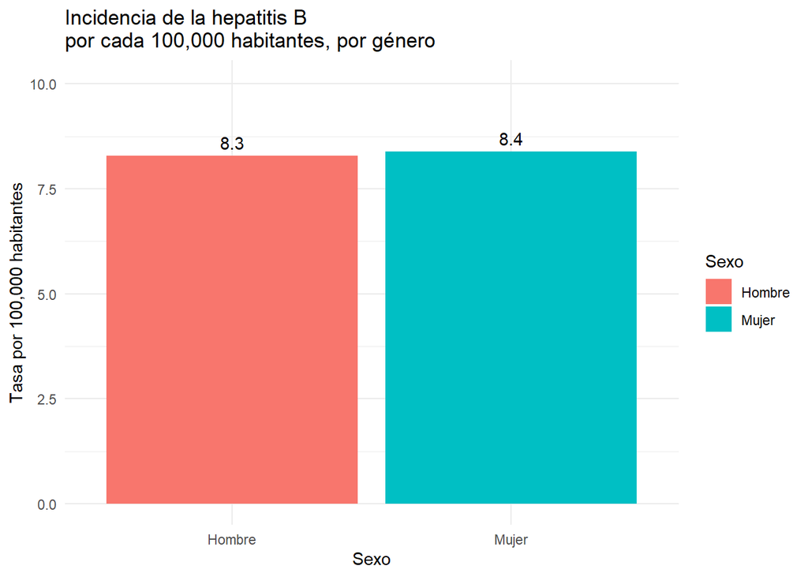

```r
ggplot(indicadorHB1_sexo, aes(x = Sexo, y = indicador, fill = Sexo)) +
  geom_bar(stat = "identity") +
  geom_text(aes(label = round(indicador, 1)), vjust = -0.5) +
  labs(
    title = "Incidencia de la hepatitis B\npor cada 100,000 habitantes, por género",
    x = "Sexo",
    y = "Tasa por 100,000 habitantes"
  ) +
  ylim(0, max(indicadorHB1_sexo$indicador) * 1.2)+
  theme_minimal()
```

```r
###por region

indicadorHB1_region <- datosHB %>%
  group_by(Región) %>%
  summarise(

    casos = n(),
    indicador = (casos / poblacion) * 100000
  )

indicadorHB1_region
```

```
## # A tibble: 9 × 3
##   Región               casos indicador
##   <chr>                <int>     <dbl>
## 1 I Valdesia              24     0.221
## 2 II Cibao Norte         352     3.24
## 3 III Cibao Nordeste     279     2.56
## 4 IV Enriquillo           63     0.579
## 5 O Metropolitana        650     5.98
## 6 V Este                 108     0.993
## 7 VI El Valle            160     1.47
## 8 VII Cibao Occidental    88     0.809
## 9 VIII Cibao Central      89     0.818
```

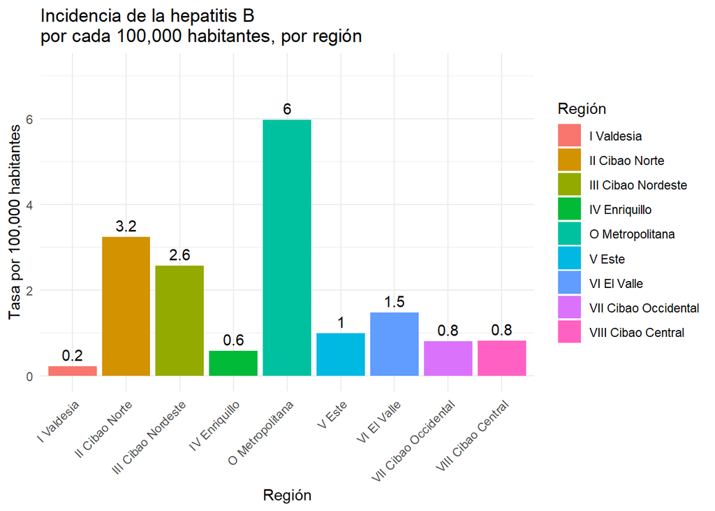

```r
ggplot(indicadorHB1_region, aes(x = Región, y = indicador, fill = Región)) +
  geom_bar(stat = "identity") +
  geom_text(aes(label = round(indicador, 1)), vjust = -0.5) +
  labs(
    title = "Incidencia de la hepatitis B\npor cada 100,000 habitantes, por región",
    x = "Región",
    y = "Tasa por 100,000 habitantes"
  ) +
  theme_minimal() +
  ylim(0, max(indicadorHB1_region$indicador) * 1.2)+
  theme(axis.text.x = element_text(angle = 45, hjust = 1))
```

```r
###por grupo etario

indicadorHB1_edad <- datosHB %>%
  group_by(`Grupo de edad`) %>%
  summarise(

    casos = n(),
    indicador = (casos / poblacion) * 100000
  )

indicadorHB1_edad
```

```
## # A tibble: 9 × 3
##   `Grupo de edad` casos indicador
##   <chr>           <int>     <dbl>
## 1 1 a 4 años          1   0.00919
## 2 10 a 19 años       26   0.239
## 3 20 a 29 años      202   1.86
## 4 30 a 39 años      410   3.77
## 5 40 a 49 años      403   3.70
## 6 5 a 9 años          1   0.00919
## 7 50 a 59 años      348   3.20
## 8 <1 año             38   0.349
## 9 >60 años          384   3.53
```

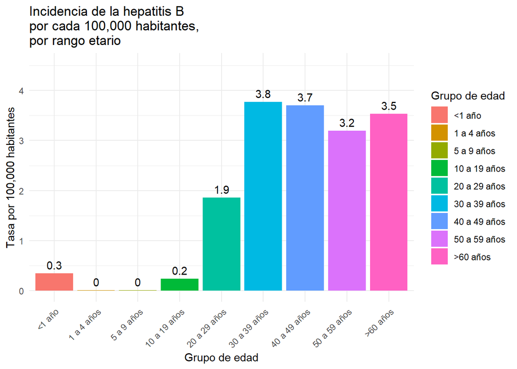

```r
####Organizar grupo etario ########
indicadorHB1_edad$`Grupo de edad` <- factor(
  indicadorHB1_edad$`Grupo de edad`,
  levels = c("<1 año", "1 a 4 años", "5 a 9 años", "10 a 19 años", "20 a 29 años", "30 a 39 años","40 a 49 años", "50 a 59 años", ">60 años")
)

ggplot(indicadorHB1_edad, aes(x = `Grupo de edad`, y = indicador, fill = `Grupo de edad`)) +
  geom_bar(stat = "identity") +
  geom_text(aes(label = round(indicador, 1)), vjust = -0.5) +
  labs(
    title = "Incidencia de la hepatitis B\npor cada 100,000 habitantes,\npor rango etario",
    x = "Grupo de edad",
    y = "Tasa por 100,000 habitantes"
  ) +
  theme_minimal() +
  ylim(0, max(indicadorHB1_edad$indicador) * 1.2)+
  theme(axis.text.x = element_text(angle = 45, hjust = 1))
```

## Interpretación

En este primer indicador podemos ver que por cada 100,000 habitantes dominicano hubo aproximadamente 16.66 personas con sospecha de hepatitis B en el año 2025. De los cuales 8.3 son hombres y 8.4 son mujeres en el rango 30 a 49 años la mayoria, concentrandose principalmente en el area metropolitana del pais.

## Indicador 2: Cobertura de aseguramiento en salud de personas con diagnóstico presuntivo de Hepatitis B

## Calculo:

$$X = \dfrac{\text{Número de casos de
Hepatitis B declarados afiliados a seguro de salud}}{\text{Total de
casos de hepatitis B declarados}} \cdot 100$$

```r
afiliados<- sum(!is.na(datosHB$ARS)) #Se utiliza !is.na para que cuente los que no sean NA.
afiliados
```

```
## [1] 946
```

```r
indicador2<-(afiliados/casos) *100
indicador2
```

```
## [1] 52.17871
```

```r
#Desagregaciones por sexo, grupo etario y region


###por sexo
indicador_sexo <- datosHB %>%
  group_by(Sexo) %>%
  summarise(
    afiliados = sum(!is.na(ARS)),
    casos = n(),
    indicador = (afiliados / casos) * 100
  )

indicador_sexo
```

```
## # A tibble: 2 × 4
##   Sexo   afiliados casos indicador
##   <chr>      <int> <int>     <dbl>
## 1 Hombre       495   901      54.9
## 2 Mujer        451   912      49.5
```

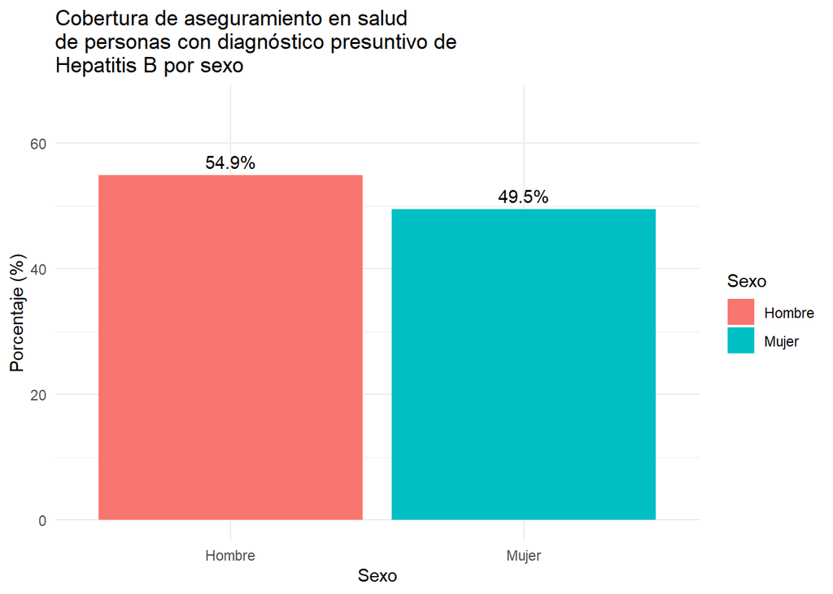

```r
ggplot(indicador_sexo, aes(x = Sexo, y = indicador, fill = Sexo)) +
  geom_bar(stat = "identity") +
  geom_text(aes(label = paste0(round(indicador, 1), "%")), vjust = -0.5) +
  labs(
    title = "Cobertura de aseguramiento en salud\nde personas con diagnóstico presuntivo de\nHepatitis B por sexo",
    x = "Sexo",
    y = "Porcentaje (%)"
  ) +
  ylim(0, max(indicador_sexo$indicador) * 1.2)+
  theme_minimal()
```

```r
###por region

indicador_region <- datosHB %>%
  group_by(Región) %>%
  summarise(
    afiliados = sum(!is.na(ARS)),
    casos = n(),
    indicador = (afiliados / casos) * 100
  )

indicador_region
```

```
## # A tibble: 9 × 4
##   Región               afiliados casos indicador
##   <chr>                    <int> <int>     <dbl>
## 1 I Valdesia                   7    24     29.2
## 2 II Cibao Norte             163   352     46.3
## 3 III Cibao Nordeste         227   279     81.4
## 4 IV Enriquillo               11    63     17.5
## 5 O Metropolitana            437   650     67.2
## 6 V Este                      19   108     17.6
## 7 VI El Valle                 10   160      6.25
## 8 VII Cibao Occidental        24    88     27.3
## 9 VIII Cibao Central          48    89     53.9
```

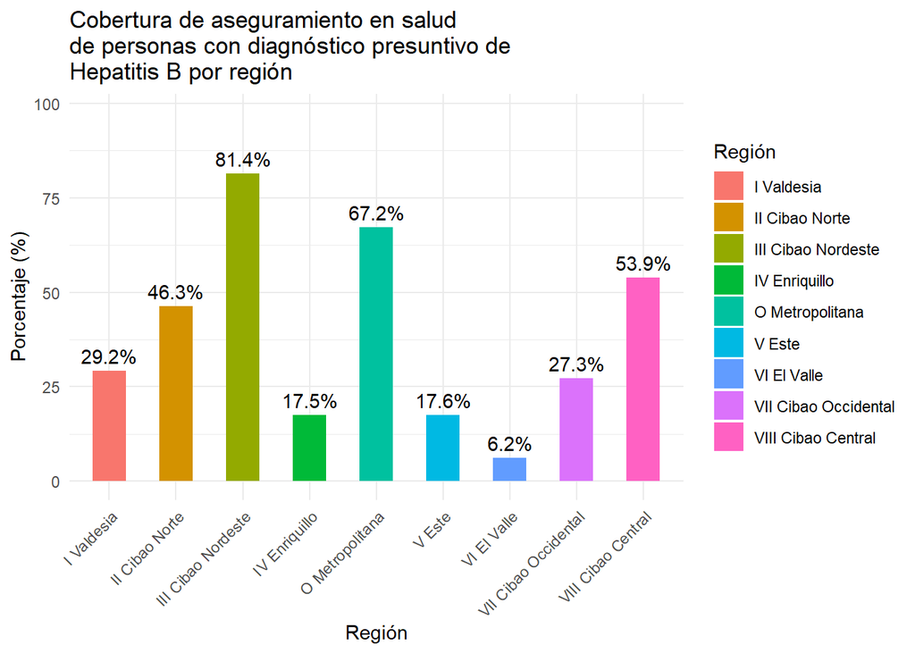

```r
ggplot(indicador_region, aes(x = Región, y = indicador, fill = Región)) +
  geom_bar(stat = "identity", width = 0.5) +
  geom_text(aes(label = paste0(round(indicador, 1), "%")), vjust = -0.5) +
  labs(
    title = "Cobertura de aseguramiento en salud\nde personas con diagnóstico presuntivo de\nHepatitis B por región",
    x = "Región",
    y = "Porcentaje (%)"
  ) +
  ylim(0, max(indicador_region$indicador) * 1.2)+
  theme_minimal() +
  theme(axis.text.x = element_text(angle = 45, hjust = 1))
```

```r
###Por grupo etario


indicador_edad <- datosHB %>%
  group_by(`Grupo de edad`) %>%
  summarise(
    afiliados = sum(!is.na(ARS)),
    casos = n(),
    indicador = (afiliados / casos) * 100
  )

indicador_edad
```

```
## # A tibble: 9 × 4
##   `Grupo de edad` afiliados casos indicador
##   <chr>               <int> <int>     <dbl>
## 1 1 a 4 años              0     1       0
## 2 10 a 19 años            5    26      19.2
## 3 20 a 29 años           53   202      26.2
## 4 30 a 39 años          190   410      46.3
## 5 40 a 49 años          237   403      58.8
## 6 5 a 9 años              0     1       0
## 7 50 a 59 años          214   348      61.5
## 8 <1 año                 10    38      26.3
## 9 >60 años              237   384      61.7
```

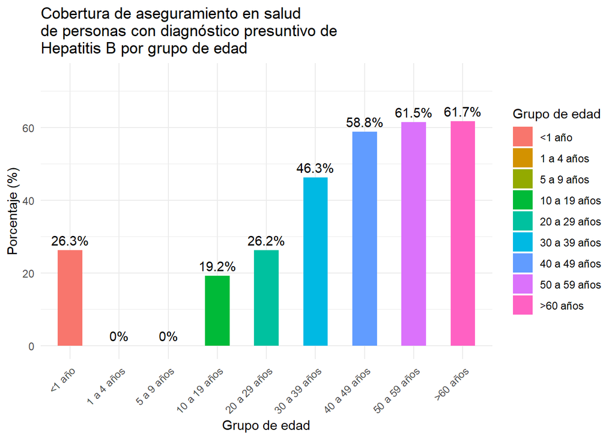

```r
####Organizar grupo etario ########
indicador_edad$`Grupo de edad` <- factor(
  indicador_edad$`Grupo de edad`,
  levels = c("<1 año", "1 a 4 años", "5 a 9 años", "10 a 19 años", "20 a 29 años", "30 a 39 años","40 a 49 años", "50 a 59 años", ">60 años")
)
ggplot(indicador_edad, aes(x = `Grupo de edad`, y = indicador, fill = `Grupo de edad`)) +
  geom_bar(stat = "identity", width = 0.5) +
  geom_text(aes(label = paste0(round(indicador, 1), "%")), vjust = -0.5) +
  labs(
    title = "Cobertura de aseguramiento en salud\nde personas con diagnóstico presuntivo de\nHepatitis B por grupo de edad",
    x = "Grupo de edad",
    y = "Porcentaje (%)"
  ) +
  theme_minimal() +
  ylim(0, max(indicador_edad$indicador) * 1.2) +
  theme(axis.text.x = element_text(angle = 45, hjust = 1))
```

## Indicador 3: prevalencia de casos de hepatitis B en pacientes con nivel educativo de bachillerato

## Calculo: (Personas con Hepatitis B en nivel educativo de bachillerato / Total de personas en ese nivel educativo) * 100

$$X = \dfrac{\text{Personas con Hepatitis
B en nivel educativo de bachillerato}}{\text{Total de personas en ese
nivel educativo}} \cdot 100$$

Nivel educativo Primaria / básica: ≈ 34.6%

Secundaria (bachillerato): ≈ 35.9%

Universitario / superior: ≈ 27.5%

Postgrado: ≈ 1.9%

```r
poblacionBachiller<-poblacion*0.359
poblacionBachiller
```

```
## [1] 3905298
```

```r
casosHB_bachiller<- length(datosHB$`Nivel educativo`[datosHB$`Nivel educativo` == "Secundaria"])
casosHB_bachiller
```

```
## [1] 412
```

```r
indicador3= (casosHB_bachiller/poblacionBachiller)*100
indicador3
```

```
## [1] 0.01054977
```

```r
###Por sexo ----se necesita la poblacion con nivel educativo de bachillerato dividida por sexo, de lo contrario se estima en base a la muestra
library(dplyr)

indicadorBachiller_sexo <- datosHB %>%
  filter(`Nivel educativo` == "Secundaria") %>%
  group_by(Sexo) %>%
  summarise(
    casos = n(),
    proporcion = casos / sum(casos)
  ) %>%
  mutate(
    poblacion_bachiller = poblacionBachiller * proporcion,
    indicador = (casos / poblacion_bachiller) * 100
  )

indicadorBachiller_sexo
```

```
## # A tibble: 2 × 5
##   Sexo   casos proporcion poblacion_bachiller indicador
##   <chr>  <int>      <dbl>               <dbl>     <dbl>
## 1 Hombre   198          1            3905298.   0.00507
## 2 Mujer    176          1            3905298.   0.00451
```

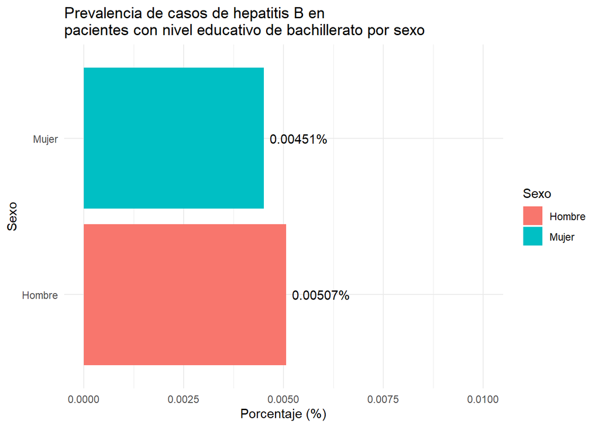

```r
ggplot(indicadorBachiller_sexo, aes(x = Sexo, y = indicador, fill = Sexo)) +
  geom_bar(stat = "identity") +
  geom_text(aes(label = paste0(round(indicador, 5), "%")), hjust = -0.1) +
  coord_flip() +
  labs(
    title = "Prevalencia de casos de hepatitis B en\npacientes con nivel educativo de bachillerato por sexo",
    x = "Sexo",
    y = "Porcentaje (%)"
  ) +
  ylim(0, max(indicadorBachiller_sexo$indicador) * 1.2) +
  scale_y_continuous(limits = c(0, 0.01)) +
  theme_minimal()
```

```r
####Por región

indicadorBachiller_region <- datosHB %>%
  filter(`Nivel educativo` == "Secundaria") %>%
  group_by(Región) %>%
  summarise(
    casos = n(),
    proporcion = casos / sum(casos)
  ) %>%
  mutate(
    poblacion_bachiller = poblacionBachiller * proporcion,
    indicador = (casos / poblacion_bachiller) * 100
  )

indicadorBachiller_region
```

```
## # A tibble: 9 × 5
##   Región               casos proporcion poblacion_bachiller indicador
##   <chr>                <int>      <dbl>               <dbl>     <dbl>
## 1 I Valdesia               8          1            3905298. 0.000205
## 2 II Cibao Norte          77          1            3905298. 0.00197
## 3 III Cibao Nordeste      16          1            3905298. 0.000410
## 4 IV Enriquillo            1          1            3905298. 0.0000256
## 5 O Metropolitana        176          1            3905298. 0.00451
## 6 V Este                  17          1            3905298. 0.000435
## 7 VI El Valle             42          1            3905298. 0.00108
## 8 VII Cibao Occidental    10          1            3905298. 0.000256
## 9 VIII Cibao Central      27          1            3905298. 0.000691
```

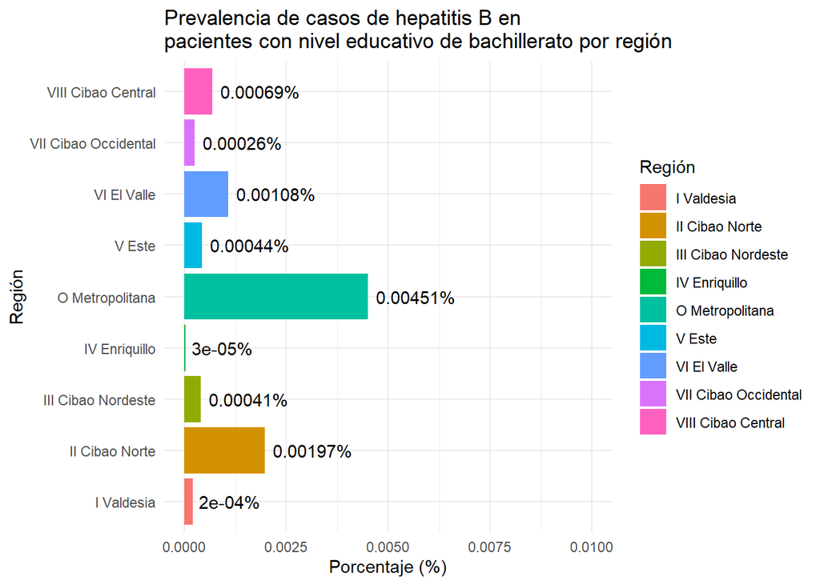

```r
ggplot(indicadorBachiller_region, aes(x = Región, y = indicador, fill = Región)) +
  geom_bar(stat = "identity") +
  geom_text(aes(label = paste0(round(indicador, 5), "%")), hjust = -0.1) +
  coord_flip() +
  labs(
    title = "Prevalencia de casos de hepatitis B en\npacientes con nivel educativo de bachillerato por región",
    x = "Región",
    y = "Porcentaje (%)"
  ) +
  ylim(0, max(indicadorBachiller_region$indicador) * 1.2)+
  scale_y_continuous(limits = c(0, 0.01))+
  theme_minimal()
```

```r
####Por grupo etario

indicadorBachiller_edad <- datosHB %>%
  filter(`Nivel educativo` == "Secundaria") %>%
  group_by(`Grupo de edad`) %>%
  summarise(
    casos = n(),
    proporcion = casos / sum(casos)
  ) %>%
  mutate(
    poblacion_bachiller = poblacionBachiller * proporcion,
    indicador = (casos / poblacion_bachiller) * 100
  )

indicadorBachiller_edad
```

```
## # A tibble: 6 × 5
##   `Grupo de edad` casos proporcion poblacion_bachiller indicador
##   <chr>           <int>      <dbl>               <dbl>     <dbl>
## 1 10 a 19 años       11          1            3905298.  0.000282
## 2 20 a 29 años       52          1            3905298.  0.00133
## 3 30 a 39 años       82          1            3905298.  0.00210
## 4 40 a 49 años      115          1            3905298.  0.00294
## 5 50 a 59 años       63          1            3905298.  0.00161
## 6 >60 años           51          1            3905298.  0.00131
```

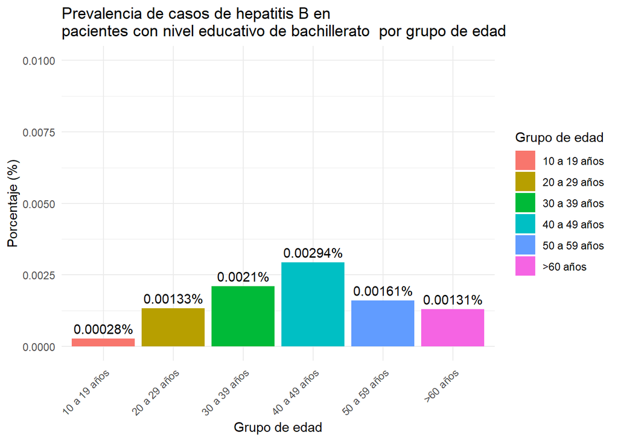

```r
indicadorBachiller_edad$`Grupo de edad` <- factor(
  indicadorBachiller_edad$`Grupo de edad`,
  levels = c("<1 año", "1 a 4 años", "5 a 9 años", "10 a 19 años", "20 a 29 años", "30 a 39 años","40 a 49 años", "50 a 59 años", ">60 años")
)

ggplot(indicadorBachiller_edad, aes(x = `Grupo de edad`, y = indicador, fill = `Grupo de edad`)) +
  geom_bar(stat = "identity") +
  geom_text(aes(label = paste0(round(indicador, 5), "%")), vjust = -0.5) +
  labs(
    title = "Prevalencia de casos de hepatitis B en\npacientes con nivel educativo de bachillerato  por grupo de edad",
    x = "Grupo de edad",
    y = "Porcentaje (%)"
  ) +
  theme_minimal() +
  ylim(0, max(indicadorHB1_sexo$indicador) * 1.2)+
  scale_y_continuous(limits = c(0, 0.01)) +
  theme(axis.text.x = element_text(angle = 45, hjust = 1))
```

## Interpretación

El indicador 3 muestra que la prevalencia de hepatitis B en personas con nivel educativo de bachillerato es relativamente baja; sin embargo, su distribución evidencia patrones importantes. Se observa una mayor concentración de casos en los grupos de edad adulta, especialmente entre los 30 y 49 años, lo que podría estar asociado a una mayor exposición acumulada a factores de riesgo. Asimismo, aunque la diferencia por sexo no es muy amplia, los hombres presentan una ligera mayor prevalencia, lo que podría reflejar diferencias en conductas de riesgo o en el acceso a los servicios de salud.

```r
# Indicador 2: afiliación a seguro
afiliados <- sum(!is.na(datosHB$ARS))
casos <- nrow(datosHB)

indicador2 <- (afiliados / casos) * 100
indicador2
```

```
## [1] 52.17871
```

# Modelado de regresión lineal en base a la edad

```r
#### Medidas de tednencia central ############

mean(datosHB$edad_num, na.rm = TRUE)
```

```
## [1] 45.96139
```

```r
median(datosHB$edad_num, na.rm = TRUE)
```

```
## [1] 45
```

```r
#### Medidas de variabilidad#####################

sd(datosHB$edad_num, na.rm = TRUE)
```

```
## [1] 16.81705
```

```r
var(datosHB$edad_num, na.rm = TRUE)
```

```
## [1] 282.8131
```

```r
### Asiemtría y curtosis

library(e1071)
skewness(datosHB$edad_num, na.rm = TRUE)
```

```
## [1] 0.04618816
```

```r
kurtosis(datosHB$edad_num, na.rm = TRUE)
```

```
## [1] 0.08375921
```

```r
#### Regresión Lineal

datos_limpios <- datosHB %>%
  filter(!is.na(`Fecha notificación`), !is.na(edad_num))

modelo <- lm(`Semana atención` ~ edad_num, data = datos_limpios)
summary(modelo)
```

```
##
## Call:
## lm(formula = `Semana atención` ~ edad_num, data = datos_limpios)
##
## Residuals:
##      Min       1Q   Median       3Q      Max
## -23.8882 -12.8529   0.1446  11.1748  28.2478
##
## Coefficients:
##              Estimate Std. Error t value Pr(>|t|)
## (Intercept) 24.749667   0.994789  24.879   <2e-16 ***
## edad_num     0.002518   0.020327   0.124    0.901
## ---
## Signif. codes:  0 '***' 0.001 '**' 0.01 '*' 0.05 '.' 0.1 ' ' 1
##
## Residual standard error: 14.55 on 1811 degrees of freedom
## Multiple R-squared:  8.476e-06,  Adjusted R-squared:  -0.0005437
## F-statistic: 0.01535 on 1 and 1811 DF,  p-value: 0.9014
```

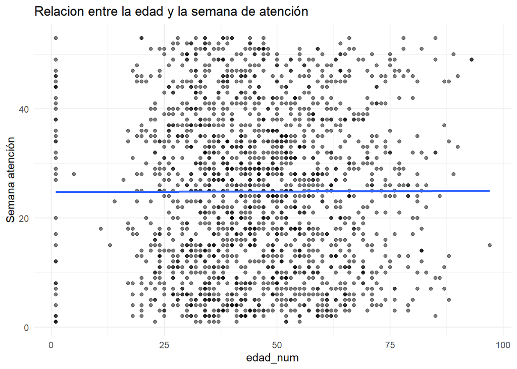

```r
#### Grafico de disperción

ggplot(datos_limpios, aes(x = edad_num, y = `Semana atención`)) +
  geom_point(alpha = 0.5) +
  labs(
    title = "Relacion entre la edad y la semana de atención"
  )+
  geom_smooth(method = "lm", se = FALSE) +
  theme_minimal()
```

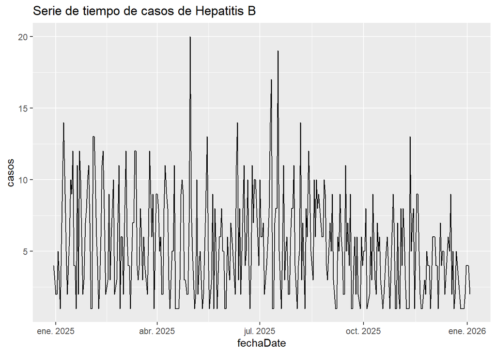

```r
### serie de tiempo

# Convertir a formato fecha
datosHB$fechaDate <- as.Date(datosHB$`Fecha atención`)

# Ordenar
datosHB <- datosHB[order(datosHB$`Fecha atención`), ]

library(dplyr)

serie <- datosHB %>%
  group_by(fechaDate) %>%
  summarise(casos = sum(Sospecha == "Hepatitis B"))


ggplot(serie, aes(x = fechaDate, y = casos)) +
  geom_line() +
  labs(title = "Serie de tiempo de casos de Hepatitis B")
```

## Interpretación

El modelo de regresión lineal muestra que no existe una relación significativa entre la edad y la semana de atención de los casos de hepatitis B, ya que el coeficiente asociado a la edad es muy cercano a cero y no resulta estadísticamente significativo. Además, el valor de R² es prácticamente nulo, lo que indica que la edad no explica la variabilidad en el momento en que los casos son atendidos. En conjunto, estos resultados sugieren que otros factores, no incluidos en el modelo, podrían estar influyendo en el comportamiento temporal de la atención de los casos.